# Vuelta Velogames Daily Update

### Top scoring teams for stage

So mark fitzpatrick cleaned up stage 20.

| team | directeur | Stage_Points |
| --- | --- | --- |
| bluebaggers | mark fitzpatrick | 436 |
| Dick`s Dodgers | Rich Johnston | 304 |
| Brake Rub Regression | Simon Lyons | 295 |
| NFI | Luke Jardine | 275 |
| Bunch of randos | Chris Fraser | 274 |
| Fake Magic | Britt Groom | 271 |
| Wilston Wippets | Peter Howes | 267 |
| Vuelta Vagabonds | David Pink | 264 |
| Ferris Wheel | Jeff Beehler | 263 |
| Opto`s Vuelta Armas | Mark Hinds | 257 |
| Ensacador De Arena | Andrew Carroll | 224 |
| Not So Smiling Assassins | Andrew Glutz | 219 |
| Team Jackal | Andrew | 217 |
| Spanish Sahara | Mick Groom | 195 |
| Thistles | Simon Scott | 192 |
| Veloderby | Julie | 148 |
| I was fast once | Dean McBeath | 108 |
| Latino Layabouts | Crooky | 56 |

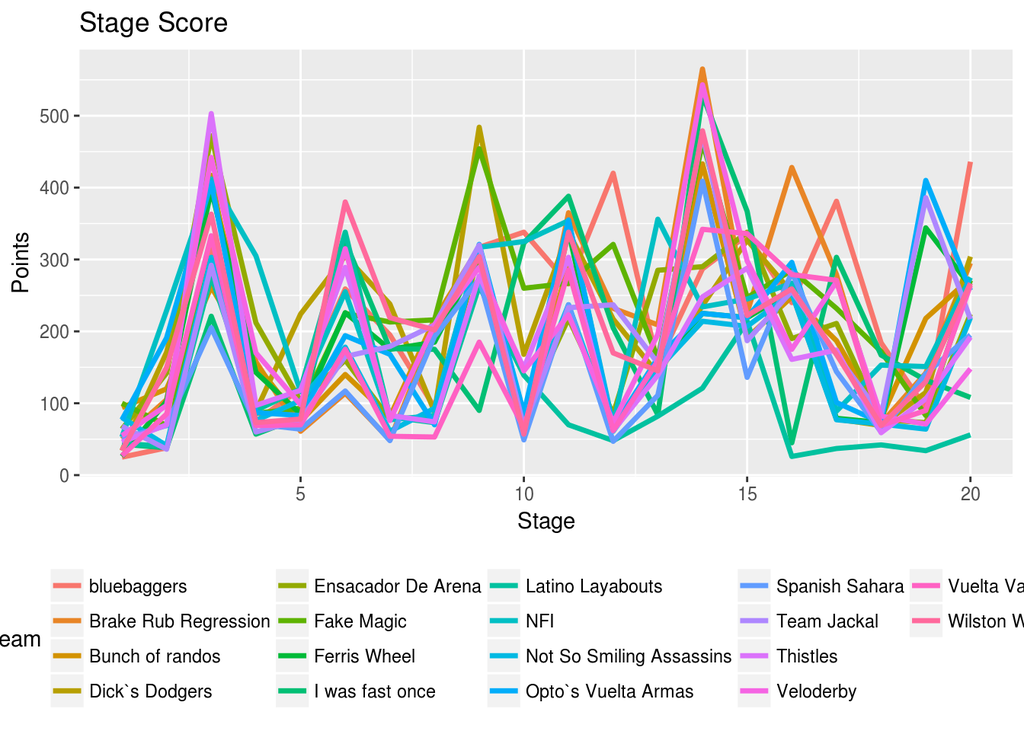

The picture for overall after 20 stages is:

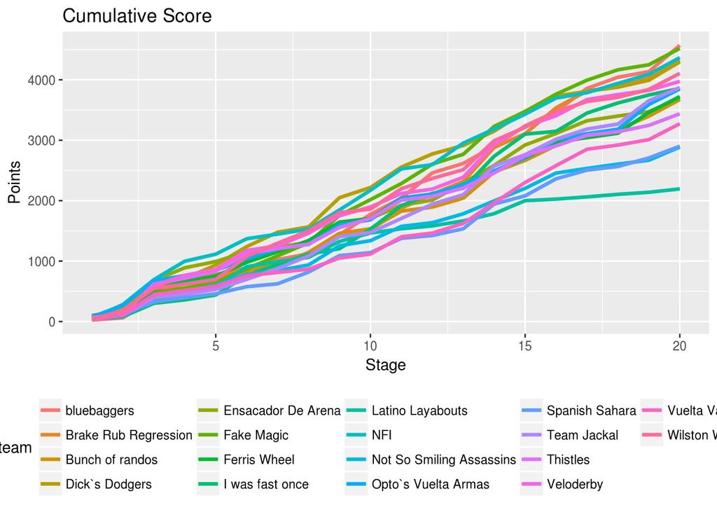

| Team | Directeur | Total |
| --- | --- | --- |
| bluebaggers | mark fitzpatrick | 4571 |
| Fake Magic | Britt Groom | 4520 |
| NFI | Luke Jardine | 4366 |
| Brake Rub Regression | Simon Lyons | 4324 |
| Dick`s Dodgers | Rich Johnston | 4297 |
| Wilston Wippets | Peter Howes | 4107 |
| Veloderby | Julie | 3974 |
| Team Jackal | Andrew | 3871 |
| I was fast once | Dean McBeath | 3857 |
| Opto`s Vuelta Armas | Mark Hinds | 3849 |
| Ferris Wheel | Jeff Beehler | 3723 |
| Ensacador De Arena | Andrew Carroll | 3697 |
| Bunch of randos | Chris Fraser | 3672 |
| Thistles | Simon Scott | 3438 |
| Vuelta Vagabonds | David Pink | 3274 |
| Spanish Sahara | Mick Groom | 2902 |
| Not So Smiling Assassins | Andrew Glutz | 2888 |
| Latino Layabouts | Crooky | 2195 |

#### Inside Look

Here’s a look inside the teams currently holding top spots on the GC podium.

Rider Scores - Top Teams

| Team | Rider | Rider Total |
| --- | --- | --- |
| bluebaggers | Alberto Contador | 966 |
| bluebaggers | Ilnur Zakarin | 960 |
| bluebaggers | José Joaquín Rojas | 682 |
| Fake Magic | Christopher Froome | 1859 |
| Fake Magic | José Joaquín Rojas | 682 |
| Fake Magic | Michael Woods | 620 |
| NFI | Christopher Froome | 1859 |
| NFI | Matteo Trentin | 1138 |
| NFI | Fabio Aru | 562 |

Next up is Stage 21.  
http://www.cyclingnews.com/vuelta-a-espana/stage-21/

### Team Cross Reference

Here’s the team breakdown for each of squads.

| rider | Times_Selected | Andrew | Andrew Carroll | Andrew Glutz | Britt Groom | Chris Fraser | Crooky | David Pink | Dean McBeath | Jeff Beehler | Julie | Luke Jardine | mark fitzpatrick | Mark Hinds | Mick Groom | Peter Howes | Rich Johnston | Simon Lyons | Simon Scott |
| --- | --- | --- | --- | --- | --- | --- | --- | --- | --- | --- | --- | --- | --- | --- | --- | --- | --- | --- | --- |
| Fabio Aru | 12 | Yes | Yes | Yes |  |  | Yes | Yes | Yes | Yes | Yes | Yes | Yes | Yes |  | Yes |  |  |  |
| Christopher Froome | 11 | Yes |  | Yes | Yes | Yes |  |  |  | Yes |  | Yes |  | Yes | Yes | Yes | Yes | Yes |  |
| Warren Barguil | 9 |  |  |  | Yes |  | Yes | Yes | Yes | Yes | Yes | Yes |  |  |  | Yes |  |  | Yes |
| Rafal Majka | 8 | Yes |  |  | Yes | Yes |  |  | Yes |  | Yes |  |  |  | Yes | Yes |  | Yes |  |
| Adam Yates | 7 |  | Yes | Yes |  | Yes | Yes |  |  |  |  |  | Yes |  |  |  | Yes |  | Yes |
| Romain Bardet | 7 |  |  |  |  |  |  |  | Yes | Yes |  | Yes |  | Yes |  | Yes | Yes |  | Yes |
| Rohan Dennis | 6 | Yes | Yes | Yes | Yes | Yes |  |  |  |  |  |  |  | Yes |  |  |  |  |  |
| Johan Esteban Chaves | 5 |  | Yes |  |  |  | Yes |  |  |  | Yes |  |  |  |  |  | Yes |  | Yes |
| Luis Leon Sanchez | 5 |  |  |  |  |  | Yes |  | Yes |  | Yes |  | Yes |  |  |  |  |  | Yes |
| Vincenzo Nibali | 5 |  | Yes |  |  |  |  | Yes |  |  | Yes |  |  |  |  |  |  | Yes | Yes |
| Adam Blythe | 3 |  |  |  |  |  |  |  |  |  |  |  |  | Yes |  | Yes | Yes |  |  |
| Bob Jungels | 3 |  |  |  |  |  |  |  |  |  |  |  |  | Yes | Yes |  |  | Yes |  |
| John Degenkolb | 3 |  |  | Yes |  |  | Yes | Yes |  |  |  |  |  |  |  |  |  |  |  |
| José Joaquín Rojas | 3 |  |  |  | Yes |  |  |  | Yes |  |  |  | Yes |  |  |  |  |  |  |
| Magnus Cort Nielsen | 3 | Yes |  |  |  |  |  |  |  |  |  |  |  |  | Yes |  |  |  | Yes |
| Omar Fraile | 3 | Yes |  |  |  |  |  |  |  |  |  |  | Yes |  |  |  |  | Yes |  |
| Simon Yates | 3 |  |  |  |  |  | Yes |  |  |  |  | Yes |  |  | Yes |  |  |  |  |
| Thomas De Gendt | 3 | Yes |  |  |  |  |  |  |  | Yes |  |  |  | Yes |  |  |  |  |  |
| Christian Knees | 2 |  |  |  |  | Yes |  |  |  |  | Yes |  |  |  |  |  |  |  |  |
| Eros Capecchi | 2 |  |  |  |  |  |  |  |  |  | Yes |  |  |  |  |  |  | Yes |  |
| George Bennett | 2 |  |  |  |  |  |  |  |  |  |  |  |  |  | Yes |  |  | Yes |  |
| Ilnur Zakarin | 2 |  |  |  |  |  |  | Yes |  |  |  |  | Yes |  |  |  |  |  |  |
| Jack Haig | 2 |  |  |  |  |  |  |  | Yes |  |  |  |  | Yes |  |  |  |  |  |
| Jens Debusschere | 2 |  |  |  |  |  |  |  |  |  | Yes |  |  |  |  |  |  | Yes |  |
| Jesús Hernández | 2 |  |  |  |  |  |  |  |  | Yes |  |  |  |  |  | Yes |  |  |  |
| José Gonçalves | 2 |  |  |  |  |  | Yes |  |  |  |  |  |  |  | Yes |  |  |  |  |
| Koen De Kort | 2 | Yes |  |  |  |  |  |  |  |  |  |  |  |  |  | Yes |  |  |  |
| Niki Terpstra | 2 |  |  |  |  |  |  | Yes | Yes |  |  |  |  |  |  |  |  |  |  |
| Pawel Poljanski | 2 |  |  |  |  |  |  |  |  |  |  |  |  |  |  | Yes | Yes |  |  |
| Sacha Modolo | 2 |  |  |  |  | Yes |  |  |  | Yes |  |  |  |  |  |  |  |  |  |
| Sam Bewley | 2 |  |  |  |  |  |  |  |  |  |  | Yes |  |  |  |  |  |  | Yes |
| Simon Clarke | 2 |  |  |  |  |  |  | Yes |  |  |  |  |  |  | Yes |  |  |  |  |
| Svein Tuft | 2 |  | Yes |  |  |  | Yes |  |  |  |  |  |  |  |  |  |  |  |  |
| Adam Hansen | 1 |  |  |  |  |  |  |  |  |  |  |  |  |  | Yes |  |  |  |  |
| Alberto Contador | 1 |  |  |  |  |  |  |  |  |  |  |  | Yes |  |  |  |  |  |  |
| Andrew Talansky | 1 |  |  |  |  |  |  |  |  |  |  |  |  | Yes |  |  |  |  |  |
| Antonio Nibali | 1 |  | Yes |  |  |  |  |  |  |  |  |  |  |  |  |  |  |  |  |
| Benjamin King | 1 |  |  |  |  |  |  |  |  | Yes |  |  |  |  |  |  |  |  |  |
| Bernardo Suaza | 1 |  |  | Yes |  |  |  |  |  |  |  |  |  |  |  |  |  |  |  |
| Brendan Canty | 1 |  |  |  | Yes |  |  |  |  |  |  |  |  |  |  |  |  |  |  |
| Carlos Betancur | 1 |  |  | Yes |  |  |  |  |  |  |  |  |  |  |  |  |  |  |  |
| David De La Cruz | 1 |  |  |  |  |  |  |  |  |  |  |  | Yes |  |  |  |  |  |  |
| Diego Rosa | 1 |  |  |  | Yes |  |  |  |  |  |  |  |  |  |  |  |  |  |  |
| Ian Stannard | 1 |  |  |  |  | Yes |  |  |  |  |  |  |  |  |  |  |  |  |  |
| Igor Anton | 1 |  |  |  |  |  |  | Yes |  |  |  |  |  |  |  |  |  |  |  |
| Jarlinson Pantano | 1 |  |  |  |  | Yes |  |  |  |  |  |  |  |  |  |  |  |  |  |
| Jimmy Turgis | 1 |  |  |  |  |  |  | Yes |  |  |  |  |  |  |  |  |  |  |  |
| Jorge Arcas | 1 |  |  |  |  |  |  |  |  |  |  |  |  |  |  |  |  |  | Yes |
| Julien Bernard | 1 |  |  |  |  |  |  |  |  |  |  | Yes |  |  |  |  |  |  |  |
| Loïc Vliegen | 1 |  |  | Yes |  |  |  |  |  |  |  |  |  |  |  |  |  |  |  |
| Marc Soler | 1 |  |  |  |  |  |  |  |  |  |  |  |  |  |  |  | Yes |  |  |
| Mark Christian | 1 |  |  |  |  |  |  |  |  |  |  | Yes |  |  |  |  |  |  |  |
| Matteo Trentin | 1 |  |  |  |  |  |  |  |  |  |  | Yes |  |  |  |  |  |  |  |
| Maxim Belkov | 1 |  |  |  |  |  |  |  |  |  |  |  |  |  |  |  | Yes |  |  |
| Michael Woods | 1 |  |  |  | Yes |  |  |  |  |  |  |  |  |  |  |  |  |  |  |
| Miguel Ángel López | 1 |  |  |  |  |  |  |  | Yes |  |  |  |  |  |  |  |  |  |  |
| Mikel Nieve | 1 |  |  |  |  | Yes |  |  |  |  |  |  |  |  |  |  |  |  |  |
| Peter Koning | 1 |  |  |  |  |  |  |  |  |  |  |  |  |  |  |  | Yes |  |  |
| Peter Stetina | 1 |  |  |  |  |  |  |  |  |  |  |  |  |  |  |  |  | Yes |  |
| Rui Costa | 1 | Yes |  |  |  |  |  |  |  |  |  |  |  |  |  |  |  |  |  |
| Sergei Chernetckii | 1 |  |  |  |  |  |  |  |  |  |  |  | Yes |  |  |  |  |  |  |
| Serge Pauwels | 1 |  |  |  |  |  |  |  |  | Yes |  |  |  |  |  |  |  |  |  |
| Steven Kruijswijk | 1 |  | Yes |  |  |  |  |  |  |  |  |  |  |  |  |  |  |  |  |
| Tejay Van Garderen | 1 |  |  |  | Yes |  |  |  |  |  |  |  |  |  |  |  |  |  |  |
| Tom Van Asbroeck | 1 |  | Yes |  |  |  |  |  |  |  |  |  |  |  |  |  |  |  |  |
| Valerio Agnoli | 1 |  |  | Yes |  |  |  |  |  |  |  |  |  |  |  |  |  |  |  |

### DNF Riders

Probably of interest to many of us at this point is which riders are no longer part of the peloton, either through accident, illness or missing the time-cut!

| Name | Nationality | Team | Pos. | Selected by |
| --- | --- | --- | --- | --- |
| John Degenkolb | Germany | Trek–Segafredo | DNS-5 | Andrew Glutz,Crooky,David Pink |
| David de la Cruz | Spain | Quick-Step Floors | DNF-20 |  |
| Rohan Dennis | Australia | BMC Racing Team | DNS-16 | Britt Groom,Chris Fraser,Andrew Glutz,Mark Hinds,Andrew,Andrew Carroll |
| Kilian Frankiny | Switzerland | BMC Racing Team | DNS-16 |  |
| Daniel Oss | Italy | BMC Racing Team | DNS-17 |  |
| Svein Tuft | Canada | Orica–Scott | DNS-16 | Andrew Carroll,Crooky |
| Jorge Arcas | Spain | Movistar Team | DNF-12 | Simon Scott |
| Carlos Betancur | Colombia | Movistar Team | DNS-7 | Andrew Glutz |
| Rubén Fernández | Spain | Movistar Team | DNF-15 |  |
| Warren Barguil | France | Team Sunweb | DNS-8 | Britt Groom,Julie,Luke Jardine,Simon Scott,Crooky,Dean McBeath,Peter Howes,David Pink,Jeff Beehler |
| Lennard Hofstede | Netherlands | Team Sunweb | DNF-12 |  |
| Lennard Kämna | Germany | Team Sunweb | DNS-17 |  |
| Sam Oomen | Netherlands | Team Sunweb | DNF-14 |  |
| Michael Kolář | Slovakia | Bora–Hansgrohe | DNF-2 |  |
| Cesare Benedetti | Italy | Bora–Hansgrohe | DNF-8 |  |
| Nico Denz | Germany | AG2R La Mondiale | DNS-16 |  |
| Axel Domont | France | AG2R La Mondiale | DNS-14 |  |
| Alexandre Geniez | France | AG2R La Mondiale | DNS-16 |  |
| Domenico Pozzovivo | Italy | AG2R La Mondiale | DNF-11 |  |
| Sven Erik Bystrøm | Norway | Team Katusha–Alpecin | DNS-8 |  |
| José Gonçalves | Portugal | Team Katusha–Alpecin | DNF-6 | Mick Groom,Crooky |
| Matvey Mamykin | Russia | Team Katusha–Alpecin | DNF-19 |  |
| George Bennett | New Zealand | LottoNL–Jumbo | DNS-12 | Mick Groom,Simon Lyons |
| Anass Ait El Abdia | Morocco | UAE Team Emirates | DNF-2 |  |
| Jesper Hansen | Denmark | Astana | DNF-8 |  |
| Jens Debusschere | Belgium | Lotto–Soudal | DNF-9 | Julie,Simon Lyons |
| Maxime Monfort | Belgium | Lotto–Soudal | DNS-18 |  |
| Javier Moreno | Spain | Bahrain–Merida | DNF-2 |  |
| Marc Fournier | France | FDJ | DNF-3 |  |
| Johan Le Bon | France | FDJ | DNF-9 |  |
| Nick Dougall | South Africa | Team Dimension Data | DNF-6 |  |
| Youcef Reguigui | Algeria | Team Dimension Data | DNF-5 |  |
| Omar Fraile | Spain | Team Dimension Data | DNF-13 | Andrew,Simon Lyons,mark fitzpatrick |
| Benjamin King | United States | Team Dimension Data | DNS-3 | Jeff Beehler |
| Merhawi Kudus | Eritrea | Team Dimension Data | DNF-7 |  |
| Serge Pauwels | Belgium | Team Dimension Data | DNS-12 | Jeff Beehler |
| Jimmy Turgis | France | Cofidis | DNF-15 | David Pink |
| Jonas Van Genechten | Belgium | Cofidis | DNF-7 |  |
| Larry Warbasse | United States | Aqua Blue Sport | DNF-7 |  |